# MPM03 - Toolbox with RMarkdown

By Eliane Albisser, Nicolasa Ana Caduff, Dominik Gabler, Michael Wechsler

# **GENERAL**

**Introduction:**

This toolbox will focus on unsupervised learning methods. Unsupervised learning is a set of statistical tools intended for the setting in which we have only a set of features measured on n observations.

In unsupervised learning, we are not interested in prediction, because we do not have an associated response variable Y. Rather, the goal is to discover interesting things about the measurements and the features. Therefore, unsupervised learning wants to visualize data in an informative way or discover subgroups among variables or among the observations.

Unsupervised learning is often performed as part of an exploratory data analysis. Often, it can be hard to assess the results obtained from unsupervised learning methods. Different from supervised methods (response variable), unsupervised learning has no way to check the work because we don’t know the true answer - the problem is unsupervised.

In this Toolbox, the following methods are covered:

- K-means
- Hierarchical Clustering (HC)
- Principal Component Analysis (PCA)
- T-distributed Stochastic Neighbor Embedding (tSNE)
- Self-organizing Maps (SOM)

**Dataset**

The default database for the toolbox is a reduced version of the FIFA 19 player dataset. It includes detailed attributes for every registered player in the FIFA 19 video game. The data set contains 40 different metrics (e.g. Salary per week, value, Dribbling, BallControl) and categorical (e.g. Position) attributes (features) for n=6699 different players (observations).

As described below, the dataset can easily be changed thanks to the usage of knitr-parameters and if-clauses.

**Toolbox structure and handling**

The Toolbox has a very dynamic structure. In the interactive user interface based on Shiny (start via: Knit/Knit with Parameters) the user can select another data set, determine data variables (first numerical and second numerical variable) for the data analyses in the toolbox and define which of the above mentioned unsupervised machine learning methods he wants to execute (checkboxes).

Of course it is not already complete, but there can easily be added some more datatypes for example. Therefore, only few changes in code are necessary.

We will highly recommend to create html-output and not pdf or word. Only if html-output is used, you can benefit from the good structure by using css and some other fancy stuff for better understanding.

Have fun!

```r
if (!require("checkpoint")) install.packages("checkpoint")
library(checkpoint)
checkpoint(snapshotDate = "2019-10-30", use.knitr = TRUE)
```

## **DATASET**

### LOADING

```r
if(params$datatype == "csv"){
  data <- read.csv(params$data, na.strings = "")
} else if(params$datatype == "csv2"){
  data <- read.csv2(params$data, na.strings = "")
} else {data <- read.table(params$data, na.strings = "")
}
saveRDS(data, file = "Data_Albisser_Caduff_Gabler_Wechsler.RDS")
```

### FIXING VARIABLES

```r
first_variable <- params$first_variable
second_variable <- params$second_variable
categorical_variable <- params$categorical_variable

data_first_variable <- data %>% pull(first_variable)
data_second_variable <- data %>% pull(second_variable)
data_categorical_variable <- data %>% pull(categorical_variable)

exploration_data <- data.frame(data_first_variable, data_second_variable)
```

### PREPARATION DIFFERENT DATASETS

Remove categorical variables

```r
data_only_numerical <- data[sapply(data, is.numeric)]
```

Select top 200 observations to make some analysis with only few records (better visualization)

```r
selection_data <- data[c(1:200),]
selection_data_only_numerical <- data_only_numerical[c(1:200),]
selection_exploration_data <- exploration_data[c(1:200),]
```

Prepare different sets for different functions (scaled and unique)

```r
scaled_data <- scale(selection_data_only_numerical)
t_scaled_data <- t(scale(selection_data_only_numerical))

data_unique <- unique(selection_data_only_numerical)
data_unique2 <- as.matrix(scale(data_unique))
```

## **EXPLORATION**

### OVERVIEW

Overview dataset: rows

```r
names(data)
```

```
 [1] "Name"                     "Age"
 [3] "Nationality"              "Overall"
 [5] "Club"                     "Value"
 [7] "Salary.per.Week"          "Acceleration"
 [9] "Aggression"               "Agility"
[11] "BallControl"              "Composure"
[13] "Contract.Valid.Until"     "Dribbling"
[15] "Finishing"                "GKDiving"
[17] "GKHandling"               "GKKicking"
[19] "GKPositioning"            "GKReflexes"
[21] "Interceptions"            "International.Reputation"
[23] "Jersey.Number"            "Jumping"
[25] "LongPassing"              "LongShots"
[27] "Penalties"                "Position"
[29] "Preferred.Foot"           "Reactions"
[31] "ShortPassing"             "ShotPower"
[33] "Skill.Moves"              "SlidingTackle"
[35] "SprintSpeed"              "Stamina"
[37] "StandingTackle"           "Strength"
[39] "Volleys"                  "Weak.Foot"
```

Overview dataset: structure

```r
str(data)
```

```
'data.frame':   6699 obs. of  40 variables:
 $ Name                    : Factor w/ 6373 levels "A. Ã–mÃ¼r","A. Ã–zbiliz",..: 3608 1167 4676 1550 3245 1659 3611 3685 5750 2906 ...
 $ Age                     : int  31 33 26 27 27 27 32 31 32 25 ...
 $ Nationality             : Factor w/ 145 levels "Afghanistan",..: 6 112 18 125 13 13 33 141 125 123 ...
 $ Overall                 : int  94 94 92 91 91 91 91 91 91 90 ...
 $ Club                    : Factor w/ 648 levels " SSV Jahn Regensburg",..: 216 331 434 376 375 140 471 216 471 64 ...
 $ Value                   : int  110500000 77000000 118500000 72000000 102000000 93000000 67000000 80000000 51000000 68000000 ...
 $ Salary.per.Week         : int  565000000 405000000 290000000 260000000 355000000 340000000 420000000 455000000 380000000 94000000 ...
 $ Acceleration            : int  91 89 94 57 78 93 80 86 76 43 ...
 $ Aggression              : int  48 63 56 38 76 54 62 87 88 34 ...
 $ Agility                 : int  91 87 96 60 79 95 93 82 78 67 ...
 $ BallControl             : int  96 94 95 42 91 94 93 90 84 16 ...
 $ Composure               : int  96 95 94 68 88 91 84 85 82 70 ...
 $ Contract.Valid.Until    : int  2021 2022 2022 2019 2023 2020 2020 2021 2020 2021 ...
 $ Dribbling               : int  97 88 96 18 86 95 90 87 63 12 ...
```

[output cut: 26 more lines]

Overview dataset: head

```r
head(data)
```

```
               Name Age Nationality Overall                Club     Value
1          L. Messi  31   Argentina      94        FC Barcelona 110500000
2 Cristiano Ronaldo  33    Portugal      94            Juventus  77000000
3         Neymar Jr  26      Brazil      92 Paris Saint-Germain 118500000
4            De Gea  27       Spain      91   Manchester United  72000000
5      K. De Bruyne  27     Belgium      91     Manchester City 102000000
6         E. Hazard  27     Belgium      91             Chelsea  93000000
  Salary.per.Week Acceleration Aggression Agility BallControl Composure
1       565000000           91         48      91          96        96
2       405000000           89         63      87          94        95
3       290000000           94         56      96          95        94
4       260000000           57         38      60          42        68
5       355000000           78         76      79          91        88
6       340000000           93         54      95          94        91
  Contract.Valid.Until Dribbling Finishing GKDiving GKHandling GKKicking
```

[output cut: 41 more lines]

### PLOTS

**Aim:**

- Exploration of the data
- Better understand the data and to see what kind of relationship there is between the predictor and the response variable

#### Standard Plot

**Description:**

- Plotting the response variable Dribbling (defined as “first_variable” above) against BallControl (defined as “second_variable” above)
- Visualization of the positions with categorical variable
- Verification of the assumption that good Dribbling skills require a good ball control
- Quantify the visual impressions with the correlation coefficient

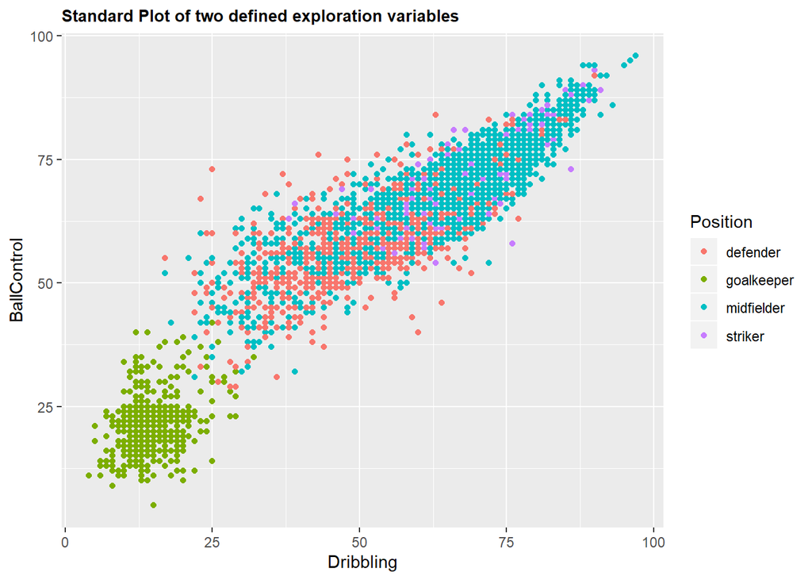

```r
ggplot(data, mapping = aes(y = data_second_variable, x = data_first_variable, color=data_categorical_variable)) +
  geom_point() +
  ggtitle("Standard Plot of two defined exploration variables") +
  theme(plot.title=element_text(size = 10, face="bold")) +
  labs(x=first_variable, y=second_variable, color=categorical_variable)
```

```r
cor(data_second_variable, data_first_variable)
```

```
[1] 0.94
```

**Interpretation:**

- As expected, there’s a clear connection between dribbling skills and ball control -> plausibility check of data
- The positive correlation between dribbling skills and ball control can be quantified with the correlation coefficient. The correlation coefficient is 0.9. Thus, there is a strong positive linear correlation between dribbling skills and ball control.
- The dot color visualizes the position of the players. It is recognisable that
  - Nearly all goalkeepers have low dribbling skills and low ball control
  - Defenders tend to have low to medium dribbling skills and ball control
  - Midfield seems to be the most popular position. They have medium to high dribbling skills and ball control
  - Strikers have medium to high dribbling skills and ball control

#### Standard Plot with regression line

**Description:**

- In the following plot, a regression line will be added to visualize the linear relationship between the exploration variables dribbling skills and ball control.
- To analyze (visualize and calculate key figures) the linear relationship of the exploration variables is important if we want to fit regression model afterwards.

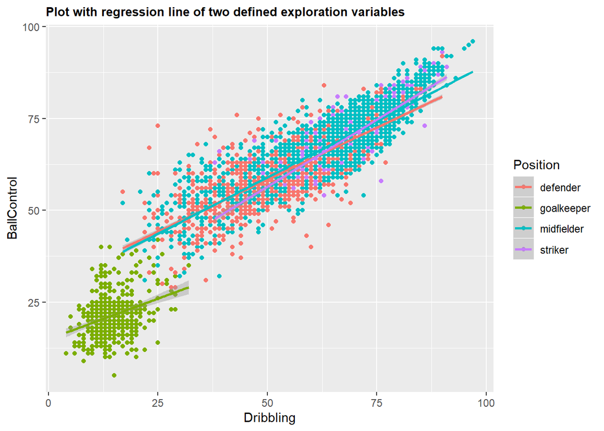

```r
ggplot(data, mapping = aes(y = data_second_variable, x = data_first_variable, color=data_categorical_variable)) +
  geom_point() +
  ggtitle("Plot with regression line of two defined exploration variables") +
  theme(plot.title=element_text(size = 10, face="bold")) +
  labs(x=first_variable, y=second_variable, color=categorical_variable) +
  geom_smooth(method = "lm")
```

**Interpretation:**

- Unsurprisingly, the regression line shows for all positions a strong positive relationship between dribbling skills and ball control.
- According to the regression line, the linear relationship between dribbling skills and ball control is highest among strikers (highest slope of the line), followed by midfielders and defenders.

#### Standard Plot with smoother

**Description:**

- The relationship of two predictors could also be non-linear.
- To verify the linearity assumption for the predictors we are adding a smoother rather than a regression line to the graph.

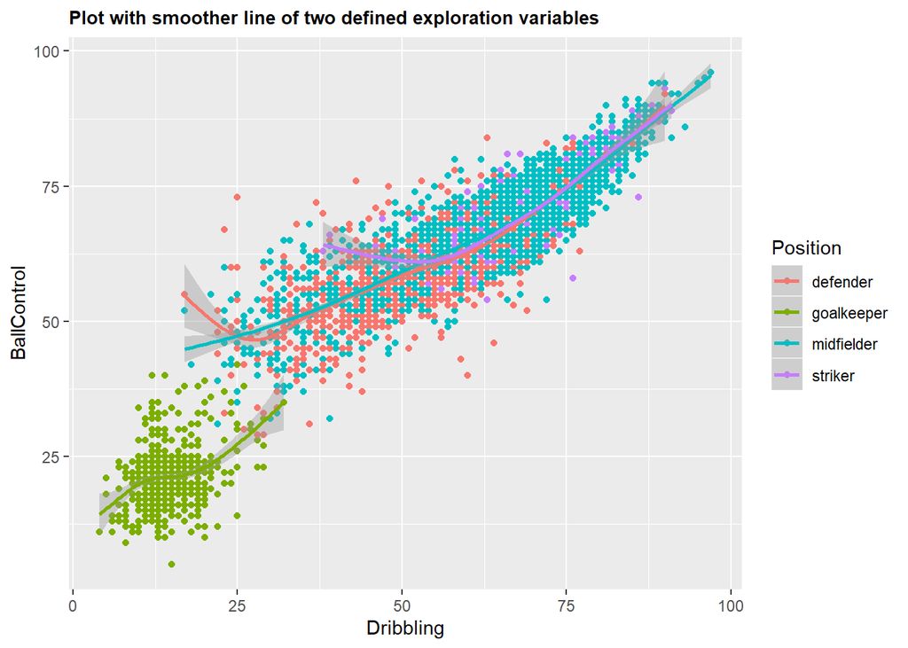

```r
ggplot(data, mapping = aes(y = data_second_variable, x = data_first_variable, color=data_categorical_variable)) +
  geom_point() +
  ggtitle("Plot with smoother line of two defined exploration variables") +
  theme(plot.title=element_text(size = 10, face="bold")) +
  labs(x=first_variable, y=second_variable, color=categorical_variable) +
  geom_smooth()
```

**Interpretation:**

- Even if the lines in the area of medium dribbling skills are a bit less straight, a very strong linear connection can still be observed in the area of high dribbling skills.
- The graph contains a lot of information and is therefore a little bit overloaded. The following approach “Paneling” may help to get a better overview.

#### Paneling

**Description:**

- Sometimes, the graphs are quite full of information and therefore no longer easy to interpret.
- A different approach to visualise the effect of the connection between Dribbling skills and BallControl for each payer position is to use “paneling”.
- Panelling means that the observation of each payer position will be plotted in a different panel.

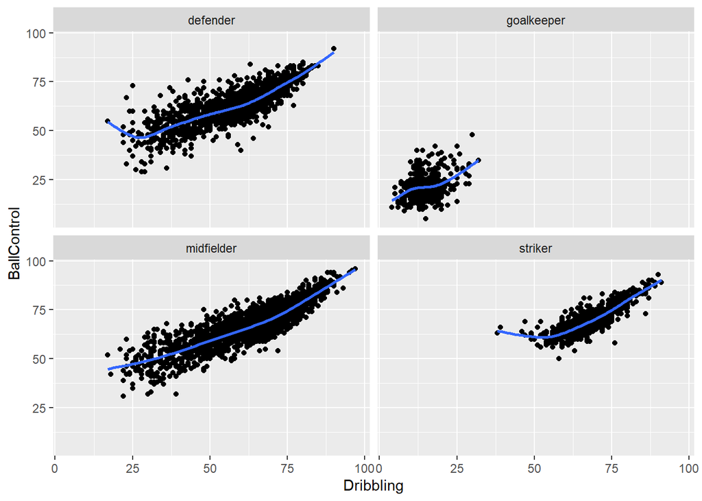

```r
ggplot(data = data,mapping = aes(y = data_second_variable,x = data_first_variable)) +
  geom_point() +
  geom_smooth(se = FALSE) +
  facet_wrap(data_categorical_variable) +
  labs(x=first_variable, y=second_variable)
```

**Interpretation:**

- Panels show the same information like the graphs before.
- Advantage is, that we can see the relationship between Dribbling skills and BallControl for each player position in a separate panel.
- As mentioned above, there is a clear positive relationship between Dribbling skills and BallControl for all positions.

#### Boxplot

**Description:**

- To see the differences in dribbling skills between the four player positions, we create a boxplot.
- Boxplots summarize data and help to outline differences in the data among a categorical variable (e.g. position).

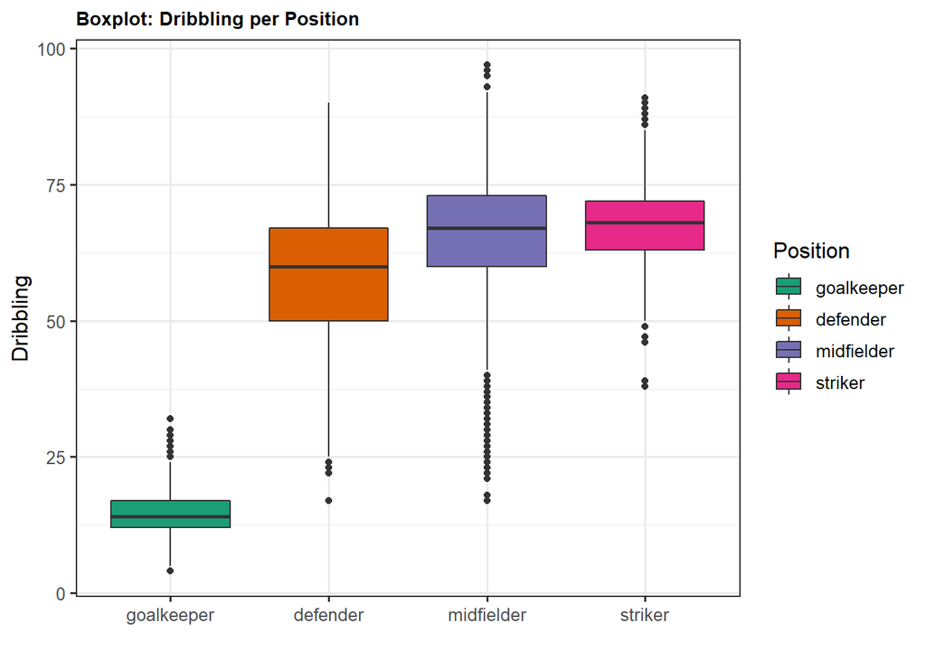

```r
ggplot(data, mapping = aes(y = data_first_variable, x = fct_reorder(data_categorical_variable, data_first_variable, .fun = median, .desc = FALSE))) +
  ggtitle(paste("Boxplot:", first_variable, "per", categorical_variable)) +
  labs(x="", y=first_variable) +
  geom_boxplot(aes(fill = fct_reorder(data_categorical_variable, data_first_variable))) +
  scale_fill_manual(values = brewer.pal(n_distinct(data_categorical_variable), "Dark2"),
                    guide = guide_legend(title = categorical_variable)) +
  theme_bw(base_size = 12) +
  theme(plot.title=element_text(size = 10, face="bold"))
```

**Interpretation:**

- It is clearly visible that the median of dribbling skills is lowest among the goalkeepers, followed by the defenders.
- The median of the dribbling skills at midfielder and strikers are about the same, with a small advantage for strikers.
- It is noticeable that the distribution of skills per position group varies strongly.
- Goalkeepers have the smallest distribution (inter-quartile-range, all low dribbling skills), while defenders have a very high spread of dribbling skills.
- Midfielders and strikers have the lower distribution compared to the defenders. Nevertheless, midfielders have a lot of outliers.

#### Boxplot alternatives

The two plots below are alternatives for plotting data with boxplots. There are similar results visible like in boxplots but visualized in a different way.

##### Jittered points

**Description:**

The following plot adds a little jitter to the data.

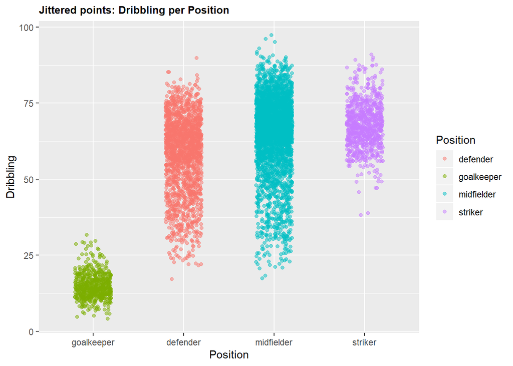

```r
ggplot(data, mapping = aes(y = data_first_variable, x = fct_reorder(data_categorical_variable, data_first_variable, .fun = median, .desc = FALSE))) +
  ggtitle(paste("Jittered points:", first_variable, "per", categorical_variable)) +
  labs(x=categorical_variable, y=first_variable, color=categorical_variable) +
  theme(plot.title=element_text(size = 10, face="bold")) +
  geom_jitter(alpha=0.5,
              aes(color=data_categorical_variable),
              position = position_jitter(width = .2))
```

##### Violin plot

**Description:**

Combination of boxplot and point plot. Shows datapoints and shows where we have most of the data.

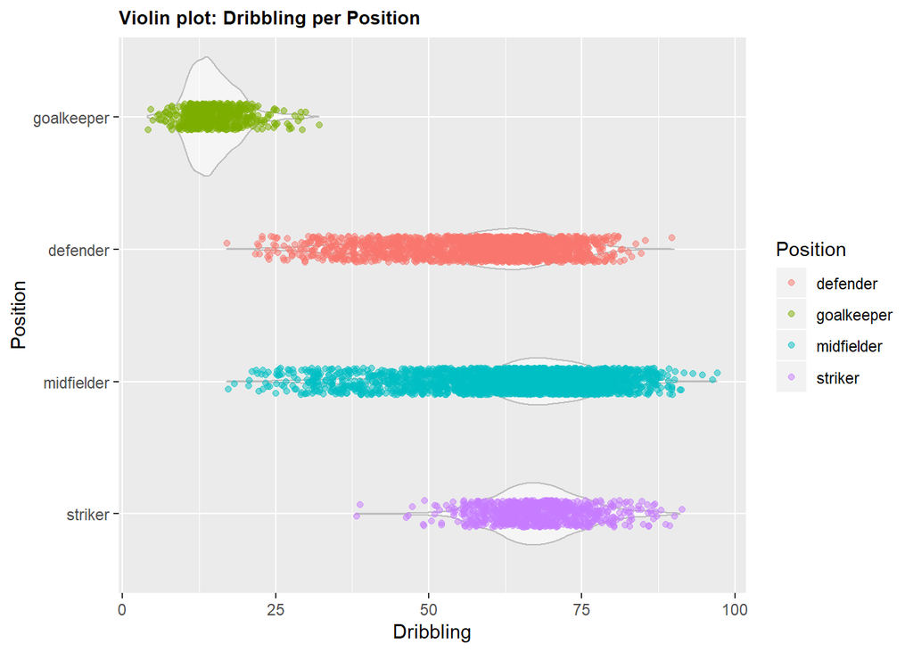

```r
ggplot(data, mapping = aes(y = data_first_variable, x = fct_reorder(data_categorical_variable, data_first_variable, .fun = median, .desc = TRUE))) +
  ggtitle(paste("Violin plot:", first_variable, "per", categorical_variable)) +
  labs(x=categorical_variable, y=first_variable, color=categorical_variable) +
  theme(plot.title=element_text(size = 10, face="bold")) +
  geom_violin(alpha=0.5, color="gray") +
  geom_jitter(alpha=0.5,
              aes(color=data_categorical_variable),
              position = position_jitter(width = 0.1))+coord_flip()
```

## **LESSON 02 / 27.09.2019**

### K-MEANS CLUSTERING

K-means clustering is a simple and elegant approach for partitioning a data set into K distinct, non-overlapping clusters. To perform K-means clustering, we must first specify the desired number of clusters K and then the K-means algorithm will assign each observation to exactly one of the clusters.

**Description:**

- Unsupervised
- Parametric (Pre-specification of K number necessary)

**Functionality:**

- Groups data based on their similarity, the resulting clusters have similar properties
- Push the data into K pre-determined categories
  - Choose a number K of cluster centers
  - Place the centers randomly in the data space (initial cluster assignment)
  - Iteratively move the centers to minimize the total within cluster variance (data-center distance)

**Aim:**

- First exploration of multidimensional data (assumption about K needed).

**Fields of application:**

- Market segmentation (e.g. identify some clusters of your customers in your company)
- Medical examination (e.g. tumour detection)
- Fraud detection

**Further information:**

- Difference between HC and k-means
  - Compared to HC, k-means need a specified number of K clusters
  - k-means forces the data into K pre-determined categories

#### Plotting k-means

**What we do? (Code)**

We create a simple two dimensional kmeans-plot with 2, 3 or 5 centroids using our definied two variables from the very beginning (Dribbling & BallControl).

Note: kmeans(x, centers, nstart), x = numeric matrix of data, centers = number of initial centers (=centroids), nstart = number of random sets

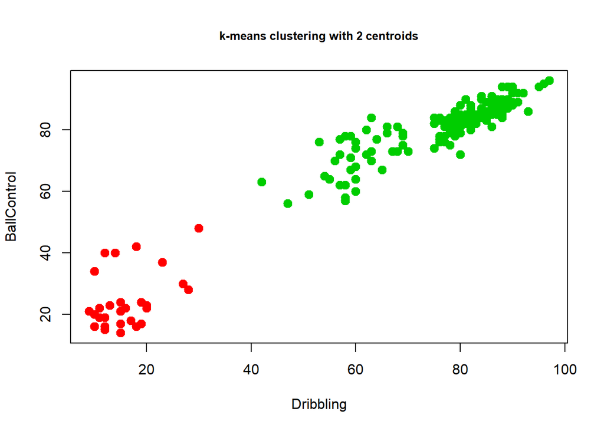

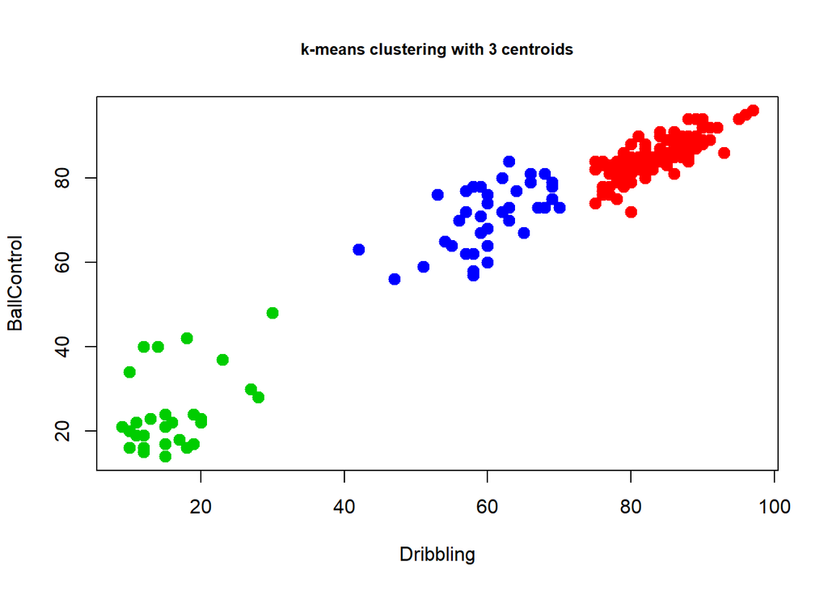

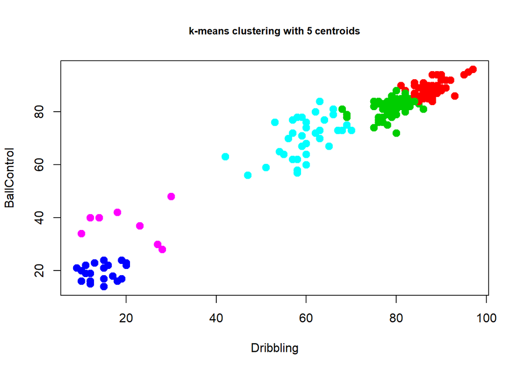

```r
km_choice <- c(2, 3, 5)
for (i in km_choice){
  km.out <- kmeans(selection_exploration_data,i,nstart =50)
  plot(selection_exploration_data,
       col = (km.out$cluster+1),
       main = paste("k-means clustering with", i, "centroids"),
       cex.main = 0.8,
       xlab = first_variable,
       ylab = second_variable,
       pch = 20, cex = 2)
}
```

```r
km.out
```

```
K-means clustering with 5 clusters of sizes 60, 75, 21, 36, 8

Cluster means:
  data_first_variable data_second_variable
1                  88                   89
2                  79                   82
3                  14                   19
4                  60                   70
5                  20                   37

Clustering vector:
  1   2   3   4   5   6   7   8   9  10  11  12  13  14  15  16  17  18
  1   1   1   5   1   1   1   1   4   3   3   1   1   4   5   2   1   2
 19  20  21  22  23  24  25  26  27  28  29  30  31  32  33  34  35  36
  1   3   2   2   2   1   1   4   1   2   1   1   1   1   2   1   1   5
```

[output cut: 30 more lines]

```r
km.out$withinss
```

```
[1] 1069 1512  447 3128  727
```

```r
km.out$tot.withinss
```

```
[1] 6884
```

**What we get? (Interpretation)**

In the next step, we will check how the different key-figures behave with a different number of centroids

#### Plotting k-means numbers

**What we do? (Code)**

We use a function to check multiple pre-determined values of K and choose the right one (reduce km.out$tot.withins)

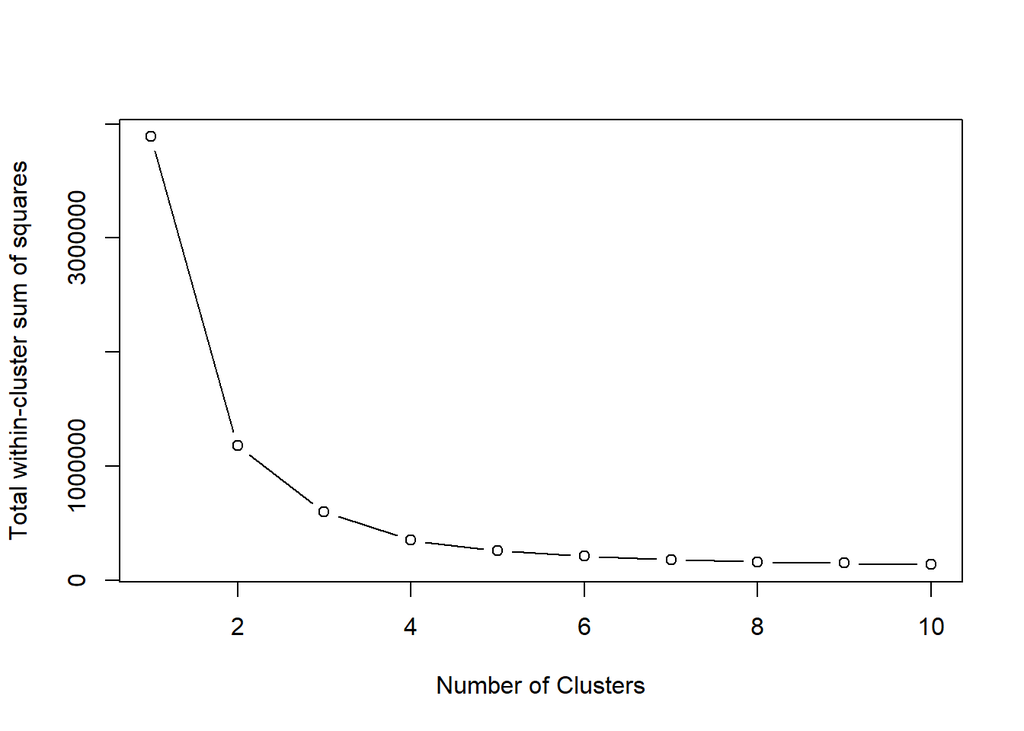

```r
wss <- 0
for (i in 1:10){
  km.out <- kmeans(exploration_data,i,nstart =50)
  wss[i] <- km.out$tot.withinss
}

plot(1:10,
     wss,
     type="b",
     xlab="Number of Clusters",
     ylab="Total within-cluster sum of squares")
```

**What we get? (Interpretation)**

- The plot shows, how the Total within-cluster sum of squares can be reduced by increasing the Number of Clusters.
- If an additional group is added, total sum squares can only decrease. The question is only how many groups make sense.
- The biggest opimatization step is visible if we increase from 1 to 2 classes. The decrease of Total within-cluster sum of squares decreases the more classes we add.
- From the increase to 6 or 7 classes, the optimization of the model becomes only minor.

### HIERARCHICAL CLUSTERING (HC) & HEAT MAPS

One potential disadvantage of K-means clustering is that it requires to pre-specify the number of clusters (K). Hierarchical clustering is an alternative approach which does not require that we commit to a particular choice of K. The method has an added advantage over K-means clustering in that it results in an attractive tree-based representation of the observations, called a dendrogram.

**Description:**

- Unsupervised
- Non-parametric
- Linkage methods: “ward.D”, “ward.D2”, “single”, “complete”, “average”, “mcquitty”, “median”,“centroid”
- Distance methods: “euclidean”, “maximum”, “manhattan”, “canberra”,“binary”, “minkowski”

**Functionality:**

- Groups data based on their similarity, the resulting clusters have similar properties
  - Bottom-up agglomerative clustering
  - Can use different metric (Euclidean-, Pearson distance)
  - Generates dendrograms that highlight similar patterns in the data set
  - Often combined to heatmaps graphical representation

**Aim:**

- First exploration of multidimensional data (no assumptions needed)

**Fields of application:**

- Market segmentation
- Medical examination (e.g. tumour detection)

**Further information:**

- Difference between HC and k-means
  - Compared to k-means, HC doesn’t need to specify k-number of clusters
  - k-means forces the data into K pre-determined categories
- Difference between HC and PCA
  - Compared to PCA, HC makes homogeneous subgroups of data that have similarities
  - PCA projects multi-dimensional data on a low-dimensional space that best summarizes data variance

#### Hierarchical Clustering (HC) with R-Standard

**What we do? (Code)**

We create a dendrogram by using the R-Standard libraries. But we need to do this with scaled data. Then we use the following methods:

- Linkage method: all possibilities
- Distance method: euclidean

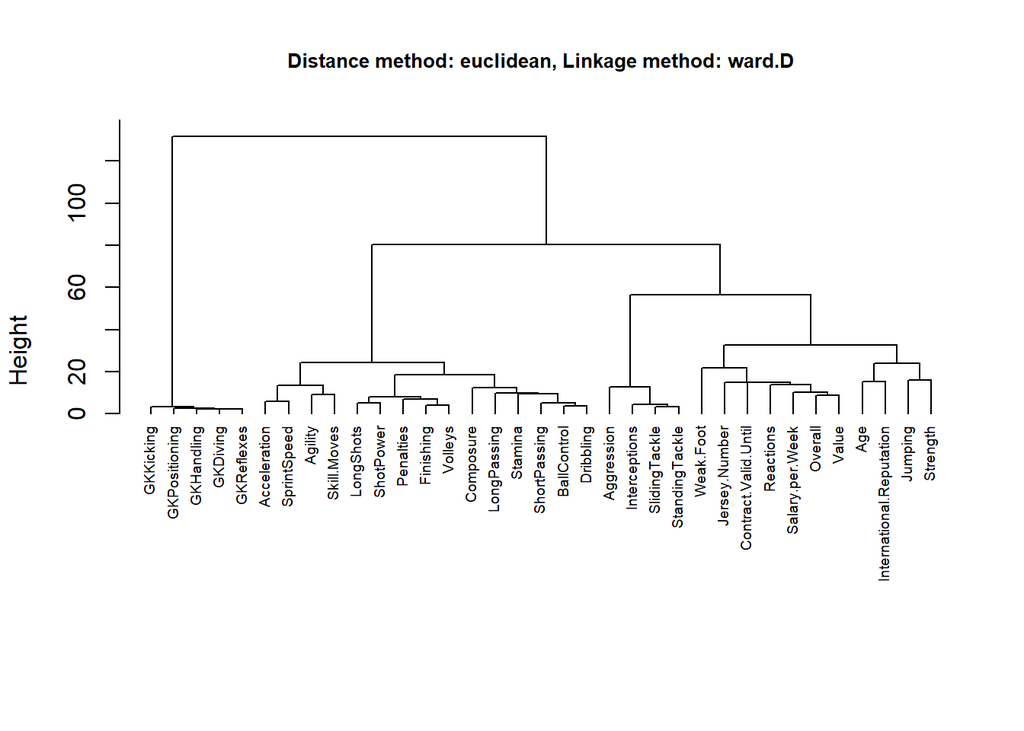

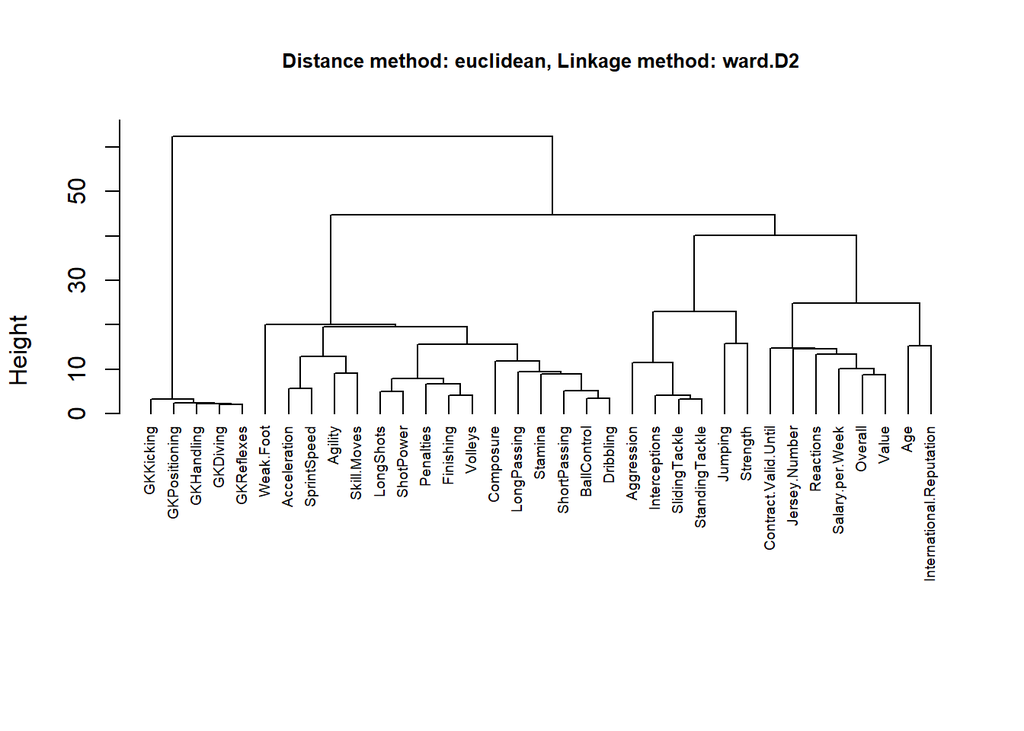

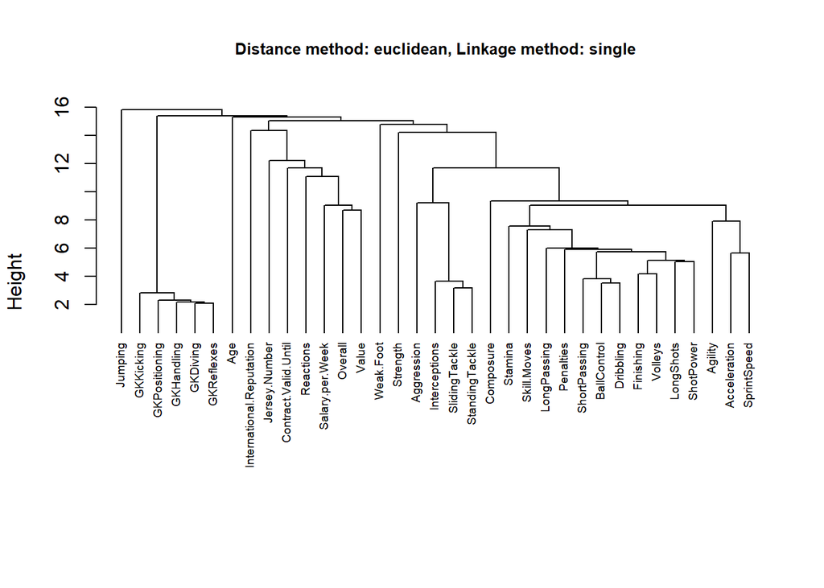

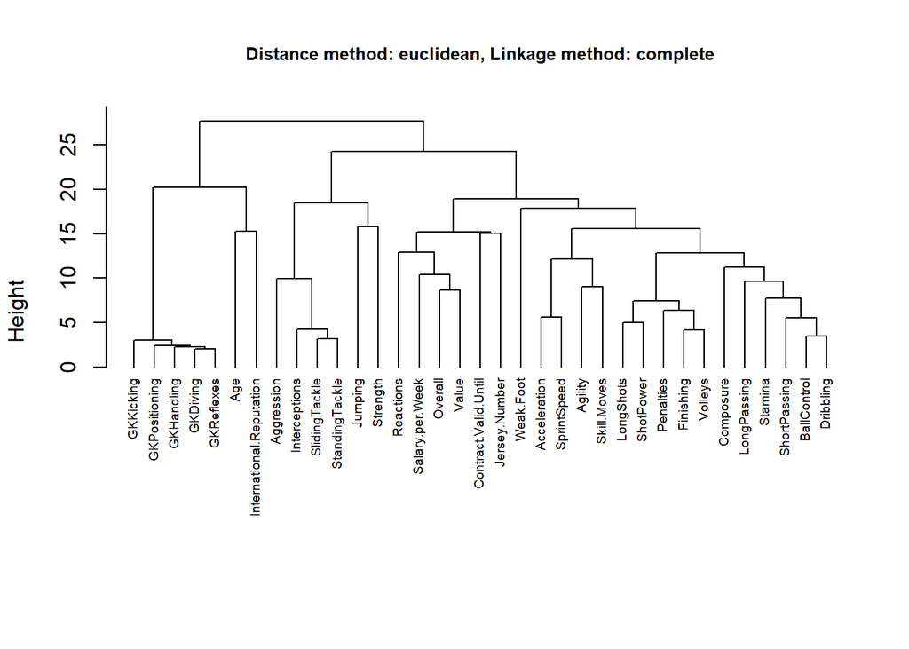

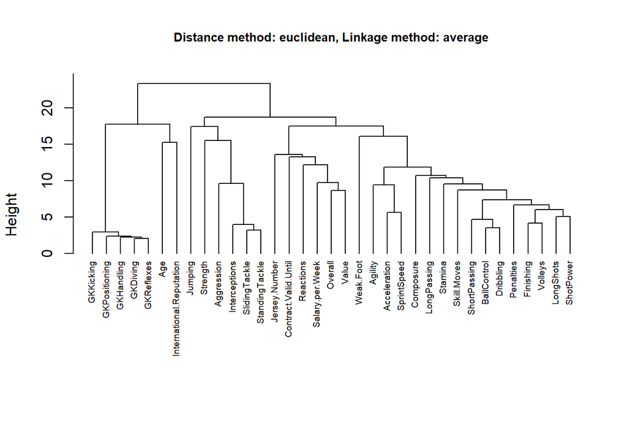

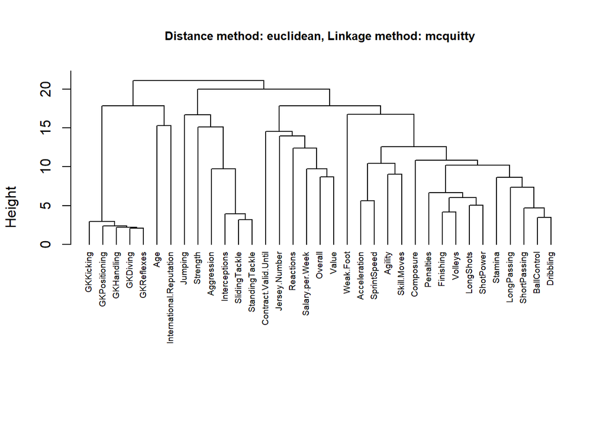

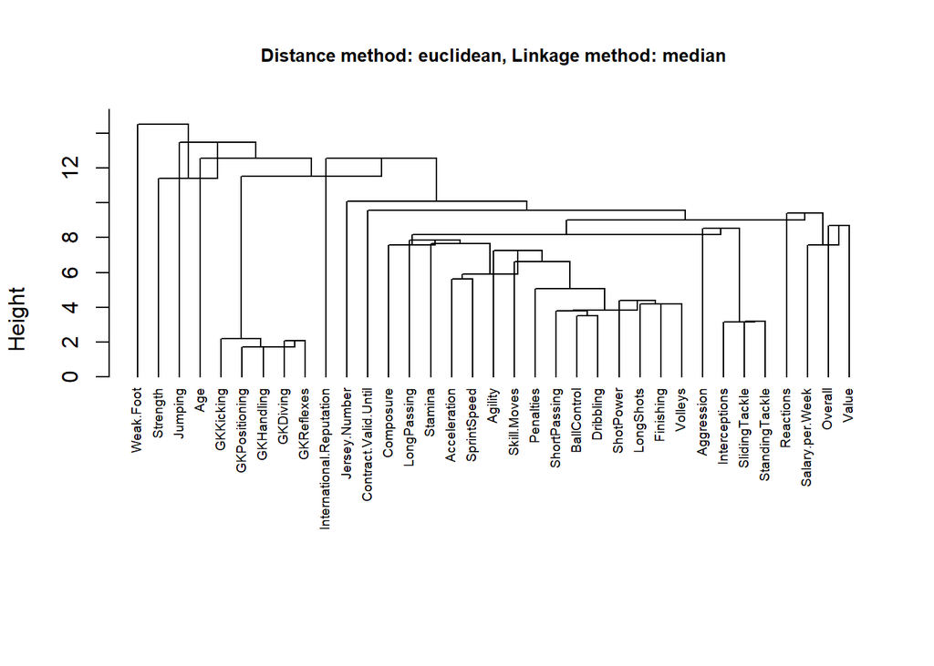

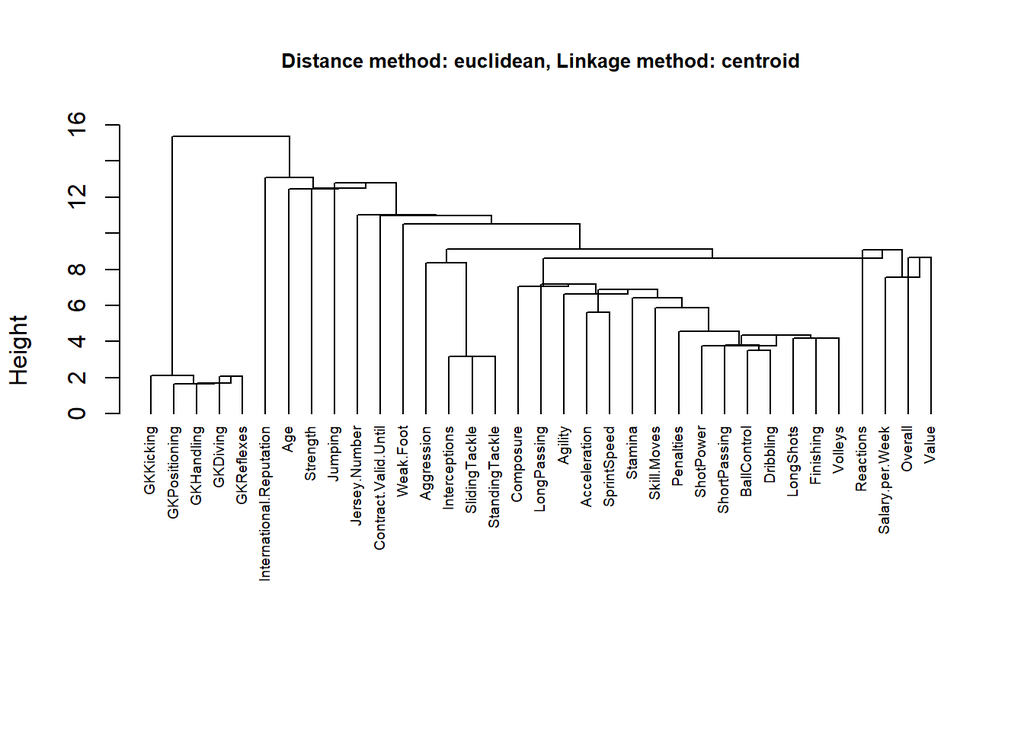

```r
hc_linkage_methods <- c("ward.D", "ward.D2", "single", "complete", "average", "mcquitty", "median","centroid")

for (i in hc_linkage_methods){
  hc_linkage <- hclust(dist(t_scaled_data, method = "euclidean"),method= i)
  plot(hc_linkage,
       main=paste("Distance method: euclidean,", "Linkage method:", i),
       cex.main=0.8,
       xlab="",
       sub="",
       hang = -1, cex = 0.6)
}
```

**What we get? (Interpretation)**

- Due to the loop, we get different Dendrograms
  - Leaf: Each leaf of the dendrogram represents one of the predictors in the dataset
  - Height: As we move up the tree, some leaves begin to fuse into branches. These correspond to predicotrs/observations that are similar to each other. The earlier (lower in the tree) fusions occur, the more similar the groups of observations are to each other. Nevertheless, the choice of where to cut the dendrogram is not always clear.
- We can see, that GK-predictors are quite similar to each other, since they fuse at the lowest point on the dendrogram. The same statement we can make for predictors Interceptions, Sliding Tackle and Standing Tackle. Moreover, we see that overall score, value and salary have a high correlation. This means, that the best players have the highest market value und earn the highest amount of money (which make sense of course).
- On the other hand, we can say that the GK-predictors are quite different from all other predictors.

#### Heatmap with R-Standard

**What we do? (Code)**

We create a basic heatmap in combination with the dendrogram information using the scaled data.

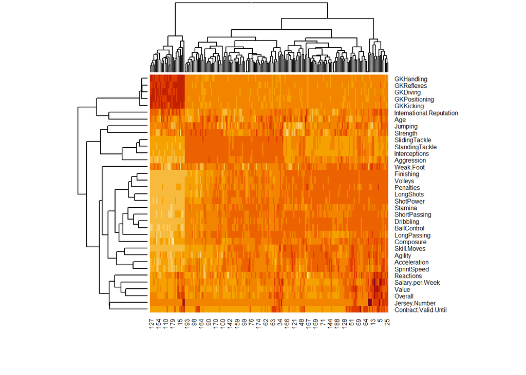

```r
heatmap(t_scaled_data,
        cexRow = 0.6,
        cexCol = 0.6)
```

#### Hierarchical Clustering (HC) with Factoextra

**What we do? (Code)**

We use the Factoextra Package, which offers a more complete library, is simpler to use and contains all methods for distance & linkage. In addition we can create a dissimilarity matrix.

- Linkage methods: “single”, “complete”, “average”, “centroid”, “ward.D”, “ward.D2”
- Distance methods (additional): “pearson”, “spearman”, “kendall”

- Linkage method: complete
- Distance method: all possibilities

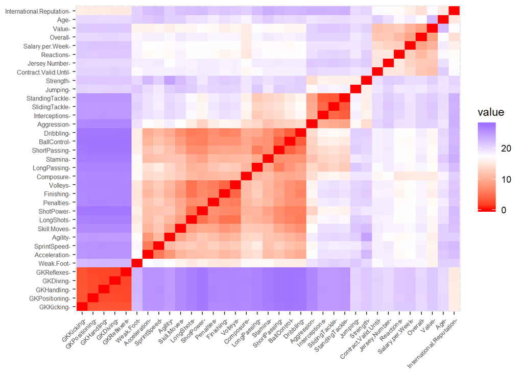

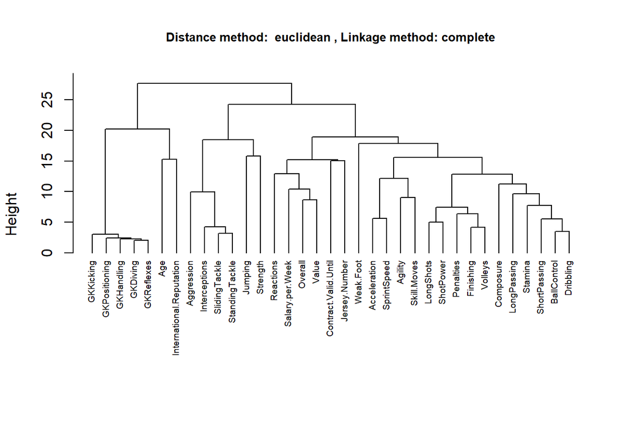

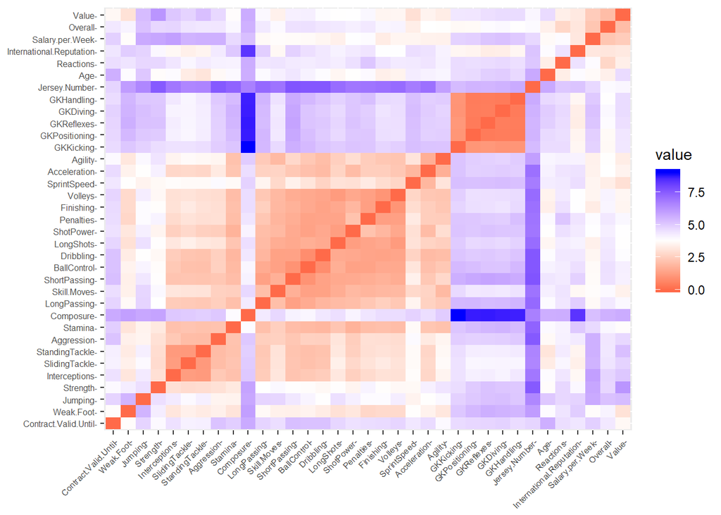

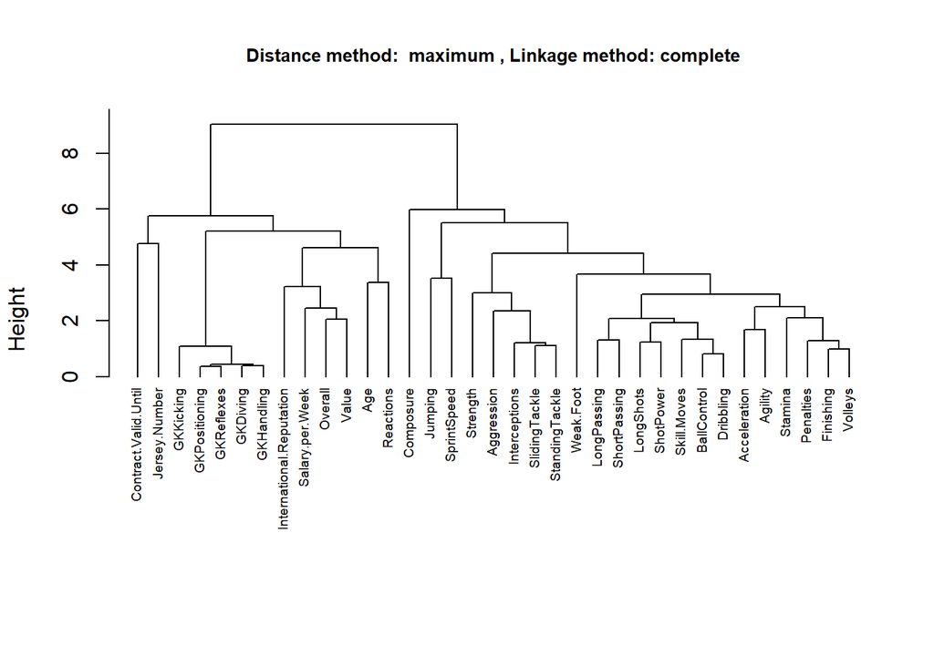

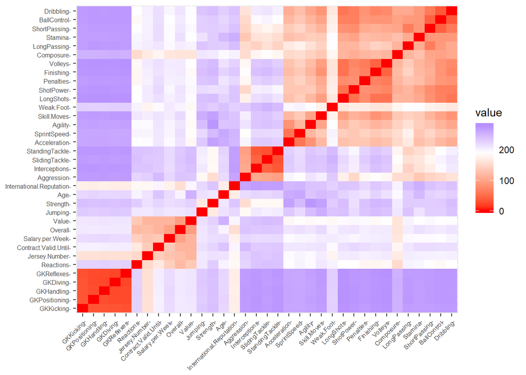

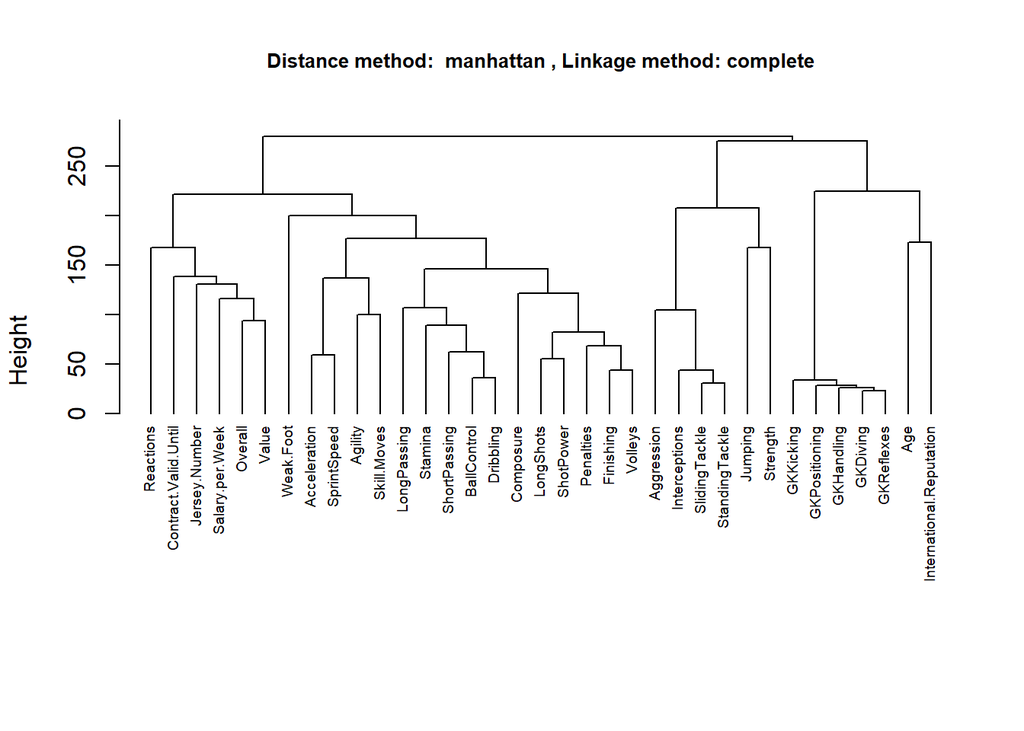

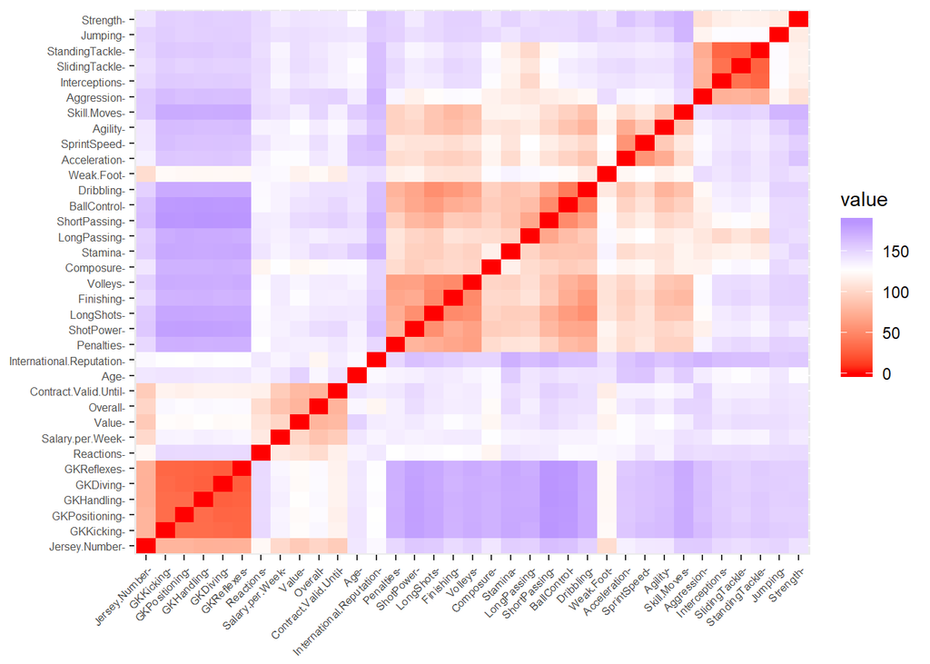

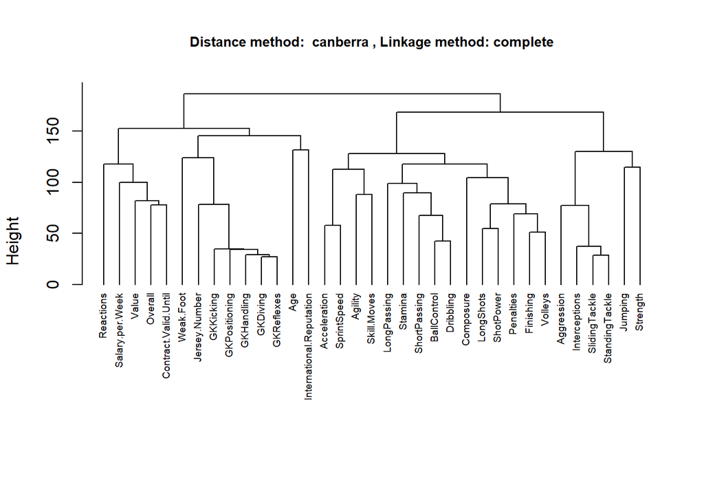

[figure not shown]

[figure not shown]

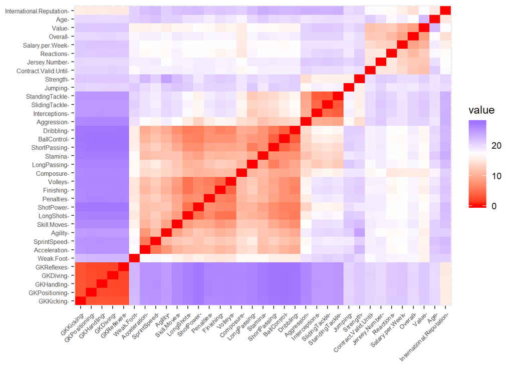

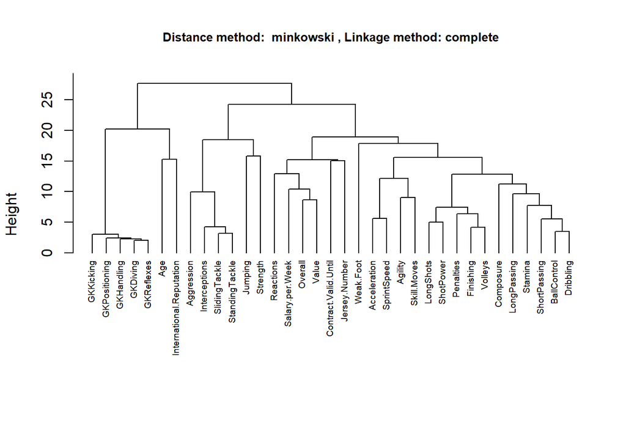

[6 more figures not shown]

```r
hc_distance_methods <- c("euclidean", "maximum", "manhattan", "canberra","binary", "minkowski", "pearson", "spearman", "kendall")

for (i in hc_distance_methods){
  res.dist <- get_dist(t_scaled_data, method = i)
  plot(fviz_dist(res.dist, lab_size = 6))
  hc_distance <- hclust(res.dist, method = "complete")
  plot(hc_distance,
       main=paste("Distance method: ", i, ", Linkage method: complete"),
       cex.main=0.8,
       xlab="",
       sub="",
       hang = -1, cex = 0.6,)
}
```